# FMST_Concrete_Strength_Protection

Project Problem Statement - FMST Problem Statement: Concrete Strength Prediction

Objective

To predict the concrete strength using the data available in file "concrete.csv". Apply feature engineering and model tuning to obtain 85% to 95% accuracy.

Resources Available

The data for this project is available in file https://archive.ics.uci.edu/ml/machine-learning-databases/concrete/compressive/. The same has been shared along with the course content.

Steps and Tasks:

### Exploratory Data Quality Report Reflecting the Following:

#### Univariate analysis(10 marks)

Data types and description of the independent attributes which should include (name, range of values observed, central values (mean and median), standard deviation and quartiles, analysis of the body of distributions/tails, missing values, outliers, duplicates(10 Marks)

#### Bi-variate analysis(10 marks)

between the predictor variables and between the predictor variables and target column. Comment on your findings in terms of their relationship and degree of relation if any. Visualize the analysis using boxplots and pair plots, histograms, or density curves.

#### Feature Engineering techniques(10 marks)

1. Identify opportunities (if any) to extract new features from existing features, drop a feature(if required) Hint: Feature Extraction, for example, consider a dataset with two features length and breadth. From this, we can extract a new feature Area which would be length * breadth.
2. Get the data model ready and do a train test split.
3. Decide on the complexity of the model, should it be a simple linear model in terms of parameters or would a quadratic or higher degree.

#### Creating the Model and Tuning It:(30 marks)

1. Algorithms that you think will be suitable for this project. Use Kfold Cross-Validation to evaluate model performance. Use appropriate metrics and make a DataFrame to compare models w.r.t their metrics. (at least 3 algorithms, one bagging and one boosting based algorithms have to be there). (15 marks)
1. Techniques employed to squeeze that extra performance out of the model without making it overfit. Use Grid Search or Random Search on any of the two models used above. Make a DataFrame to compare models after hyperparameter tuning and their metrics as above. (15 marks)

Attribute Information:

Given are the variable name, variable type, the measurement unit, and a brief description. The concrete compressive strength is the regression problem. The order of this listing corresponds to the order of numerals along the rows of the database.

Name Data Type Measurement Description

1. Cement (cement) quantitative kg in a m3 mixture Input Variable
2. Blast Furnace Slag (slag) quantitative kg in a m3 mixture Input Variable
3. Fly Ash (ash) quantitative kg in a m3 mixture Input Variable
4. Water(water) quantitative kg in a m3 mixture Input Variable
5. Superplasticizer (superplastic) quantitative kg in a m3 mixture Input Variable
6. Coarse Aggregate (coarseagg) quantitative kg in a m3 mixture Input Variable
7. Fine Aggregate (fineagg) quantitative kg in a m3 mixture Input Variable
8. Age(age) quantitative Day (1~365) Input Variable
9. Concrete compressive strength(strength) quantitative MPa Output Variable

### Univariate Analysis (10)

```python
#Importing necessary libraries
%matplotlib inline
import numpy as np
import pandas as pd
import matplotlib.pyplot as plt
import seaborn as sns
import warnings
warnings.filterwarnings("ignore")
```

```python
#Importing the libraries for machine learning
from sklearn.model_selection import train_test_split, KFold, cross_val_score, GridSearchCV, RandomizedSearchCV
from sklearn.metrics import r2_score
from sklearn.preprocessing import RobustScaler
from sklearn.preprocessing import PolynomialFeatures

# Machine Learning Models
from sklearn.linear_model import LogisticRegression
from sklearn.linear_model import LinearRegression, Ridge, Lasso
from sklearn.tree import DecisionTreeRegressor
from sklearn.ensemble import RandomForestRegressor, GradientBoostingRegressor, AdaBoostRegressor, BaggingRegressor
from xgboost import XGBRegressor

import warnings
warnings.simplefilter(action='ignore', category=FutureWarning)
```

```python
#Importing the dataframe
df1_concrete = pd.read_csv("concrete.csv")
```

```python
df1_concrete.head()
```

|  | cement | slag | ash | water | superplastic | coarseagg | fineagg | age | strength |
| --- | --- | --- | --- | --- | --- | --- | --- | --- | --- |
| 0 | 141.3 | 212.0 | 0.0 | 203.5 | 0.0 | 971.8 | 748.5 | 28 | 29.89 |
| 1 | 168.9 | 42.2 | 124.3 | 158.3 | 10.8 | 1080.8 | 796.2 | 14 | 23.51 |
| 2 | 250.0 | 0.0 | 95.7 | 187.4 | 5.5 | 956.9 | 861.2 | 28 | 29.22 |
| 3 | 266.0 | 114.0 | 0.0 | 228.0 | 0.0 | 932.0 | 670.0 | 28 | 45.85 |
| 4 | 154.8 | 183.4 | 0.0 | 193.3 | 9.1 | 1047.4 | 696.7 | 28 | 18.29 |

```python
#Shape of the dataset
df1_concrete.shape
```

```
(1030, 9)
```

```python
#datatype of all the columns
df1_concrete.info()
```

```
<class 'pandas.core.frame.DataFrame'>
RangeIndex: 1030 entries, 0 to 1029
Data columns (total 9 columns):
 #   Column        Non-Null Count  Dtype
---  ------        --------------  -----
 0   cement        1030 non-null   float64
 1   slag          1030 non-null   float64
 2   ash           1030 non-null   float64
 3   water         1030 non-null   float64
 4   superplastic  1030 non-null   float64
 5   coarseagg     1030 non-null   float64
 6   fineagg       1030 non-null   float64
 7   age           1030 non-null   int64
 8   strength      1030 non-null   float64
dtypes: float64(8), int64(1)
memory usage: 72.5 KB
```

```python
#checking the the number of missing values in each column
df1_concrete.isna().sum()
```

```
cement          0
slag            0
ash             0
water           0
superplastic    0
coarseagg       0
fineagg         0
age             0
strength        0
dtype: int64
```

```python
#Descriptive analysis of the dataset
df1_concrete.describe().T
```

|  | count | mean | std | min | 25% | 50% | 75% | max |
| --- | --- | --- | --- | --- | --- | --- | --- | --- |
| cement | 1030.0 | 281.167864 | 104.506364 | 102.00 | 192.375 | 272.900 | 350.000 | 540.0 |
| slag | 1030.0 | 73.895825 | 86.279342 | 0.00 | 0.000 | 22.000 | 142.950 | 359.4 |
| ash | 1030.0 | 54.188350 | 63.997004 | 0.00 | 0.000 | 0.000 | 118.300 | 200.1 |
| water | 1030.0 | 181.567282 | 21.354219 | 121.80 | 164.900 | 185.000 | 192.000 | 247.0 |
| superplastic | 1030.0 | 6.204660 | 5.973841 | 0.00 | 0.000 | 6.400 | 10.200 | 32.2 |
| coarseagg | 1030.0 | 972.918932 | 77.753954 | 801.00 | 932.000 | 968.000 | 1029.400 | 1145.0 |
| fineagg | 1030.0 | 773.580485 | 80.175980 | 594.00 | 730.950 | 779.500 | 824.000 | 992.6 |
| age | 1030.0 | 45.662136 | 63.169912 | 1.00 | 7.000 | 28.000 | 56.000 | 365.0 |
| strength | 1030.0 | 35.817961 | 16.705742 | 2.33 | 23.710 | 34.445 | 46.135 | 82.6 |

##### Outcome:

1. We can observe from the above data analys that there are some 0 values in slag, ash and superplastic columns. So we can treat those 0 values by imputing with mean alues.

```python
#replacing the 0 values with their mean value
df1_concrete["slag"] = df1_concrete.slag.replace(to_replace = 0, value = df1_concrete.slag.mean())
df1_concrete["ash"] = df1_concrete.ash.replace(to_replace = 0, value = df1_concrete.ash.mean())
df1_concrete["superplastic"] = df1_concrete.superplastic.replace(to_replace = 0, value = df1_concrete.superplastic.mean())
df1_concrete.describe().T
```

|  | count | mean | std | min | 25% | 50% | 75% | max |
| --- | --- | --- | --- | --- | --- | --- | --- | --- |
| cement | 1030.0 | 281.167864 | 104.506364 | 102.00 | 192.375000 | 272.900000 | 350.000 | 540.0 |
| slag | 1030.0 | 107.687023 | 61.658049 | 11.00 | 73.895825 | 73.895825 | 142.950 | 359.4 |
| ash | 1030.0 | 83.965637 | 39.911375 | 24.50 | 54.188350 | 54.188350 | 118.300 | 200.1 |
| water | 1030.0 | 181.567282 | 21.354219 | 121.80 | 164.900000 | 185.000000 | 192.000 | 247.0 |
| superplastic | 1030.0 | 8.487734 | 4.036065 | 1.70 | 6.204660 | 6.400000 | 10.200 | 32.2 |
| coarseagg | 1030.0 | 972.918932 | 77.753954 | 801.00 | 932.000000 | 968.000000 | 1029.400 | 1145.0 |
| fineagg | 1030.0 | 773.580485 | 80.175980 | 594.00 | 730.950000 | 779.500000 | 824.000 | 992.6 |
| age | 1030.0 | 45.662136 | 63.169912 | 1.00 | 7.000000 | 28.000000 | 56.000 | 365.0 |
| strength | 1030.0 | 35.817961 | 16.705742 | 2.33 | 23.710000 | 34.445000 | 46.135 | 82.6 |

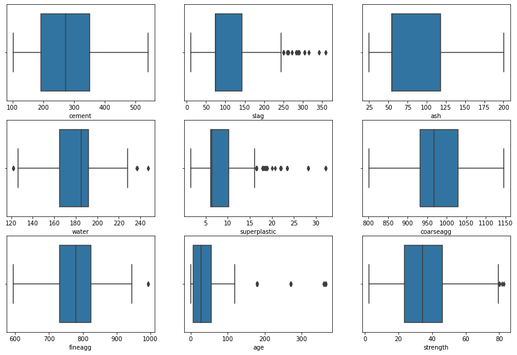

```python
#Displaying box plots for all the columns to check the outliers
plt.figure(figsize = (15,10))
cols = 1
for column in df1_concrete.select_dtypes(include=[np.number]).columns:
    plt.subplot(3, 3, cols)
    box_plot = sns.boxplot(df1_concrete[column])
    cols += 1
```

```python
#Calculation of outliers in each column
q1 = df1_concrete.quantile(0.25)
q3 = df1_concrete.quantile(0.75)
IQR = q3 - q1
outlier = ((df1_concrete.iloc[:] < (q1 - 1.5 * IQR)) | (df1_concrete.iloc[:] > (q3 + 1.5 * IQR))).sum(axis = 0)
outlier_df = pd.DataFrame(outlier, index = df1_concrete.columns, columns = ["Number of Outliers"])
outlier_df["Outliers in %"] = round(outlier_df["Number of Outliers"] * 100 / len(df1_concrete), 2)
outlier_df
```

|  | Number of Outliers | Outliers in % |
| --- | --- | --- |
| cement | 0 | 0.00 |
| slag | 35 | 3.40 |
| ash | 0 | 0.00 |
| water | 9 | 0.87 |
| superplastic | 51 | 4.95 |
| coarseagg | 0 | 0.00 |
| fineagg | 5 | 0.49 |
| age | 59 | 5.73 |
| strength | 4 | 0.39 |

As we can observe the percentage of outliers in each column is less than 6%, so we can leave the dataset as it is. This less number of outliers should not have impact on Ensemble technique.

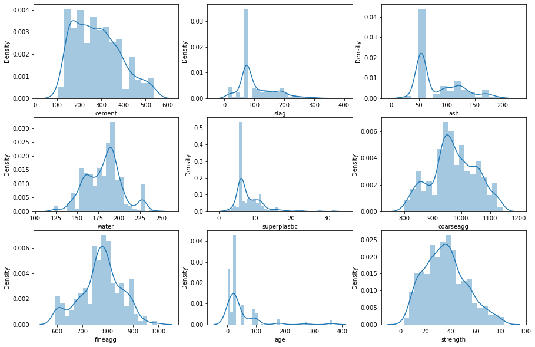

```python
#Displaying distribution plots for all the columns
plt.figure(figsize = (15,10))
cols = 1
for column in df1_concrete.select_dtypes(include=[np.number]).columns:
    plt.subplot(3, 3, cols)
    dis_plot = sns.distplot(df1_concrete[column])
    cols += 1
```

### Bivariate Analysis (10)

```python
#lets split the dependent and independent variables
#(i.e. showing the relationship between strength column with all the other columns)
X = df1_concrete.loc[:, df1_concrete.columns != 'strength']
y = df1_concrete['strength']
```

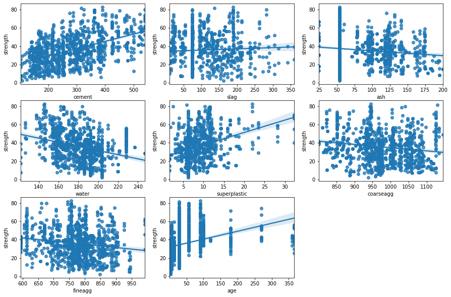

```python
#Showing the relationship between dependent and independent variables in regression plot
plt.figure(figsize=(15, 10))
cols = 1
for i in df1_concrete.drop(columns = 'strength').columns:
    plt.subplot(3, 3, cols)
    sns.regplot(x = X[i], y = y, data = df1_concrete)
    cols += 1
```

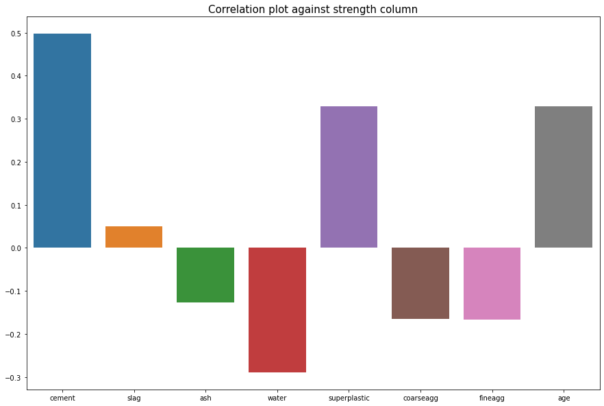

```python
#let's plot the correlation plot between strength and rest of the columns
plt.figure(figsize = (15, 10))
sns.barplot(x = X.columns, y = X.corrwith(y))
plt.title('Correlation plot against strength column', fontsize = 15)
```

```python
X.apply(lambda x: x.corr(y))
```

```
cement          0.497832
slag            0.050145
ash            -0.126936
water          -0.289633
superplastic    0.328293
coarseagg      -0.164935
fineagg        -0.167241
age             0.328873
dtype: float64
```

-> As we can see the columns cement, slag, superplastic and age have the positive correlation with strength whereas ash, water, coarseagg and fineagg have neagtive correlation with strength.

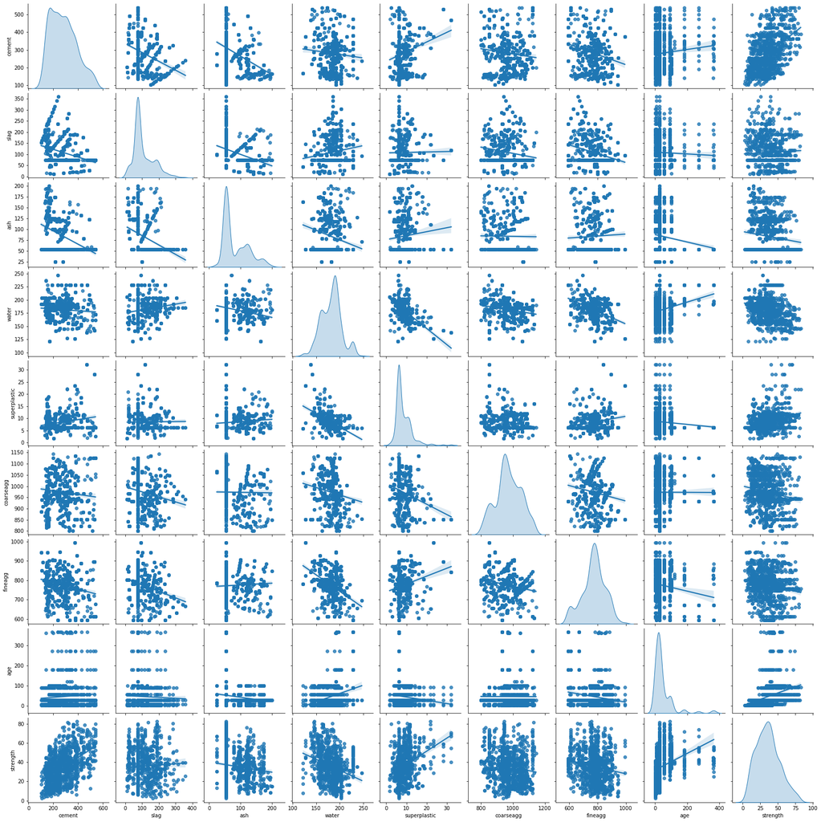

```python
#Pairplot to show the relationship between all the columns
sns.pairplot(df1_concrete, kind = "reg", diag_kind = "kde")
```

### Feature Engineering Techniques(10)

```python
#lets make the copy of dataset before making any significant changes
df2_concrete = df1_concrete.copy()
```

```python
#lets combine the two columns coarseagg and fineagg to form a single column agg
df2_concrete['agg'] = df2_concrete['coarseagg'] + df2_concrete['fineagg']
df2_concrete.drop(columns = ['coarseagg', 'fineagg'], inplace = True)
df2_concrete.columns
```

```
Index(['cement', 'slag', 'ash', 'water', 'superplastic', 'age', 'strength',
       'agg'],
      dtype='object')
```

```python
df2_concrete.head()
```

|  | cement | slag | ash | water | superplastic | age | strength | agg |
| --- | --- | --- | --- | --- | --- | --- | --- | --- |
| 0 | 141.3 | 212.000000 | 54.18835 | 203.5 | 6.20466 | 28 | 29.89 | 1720.3 |
| 1 | 168.9 | 42.200000 | 124.30000 | 158.3 | 10.80000 | 14 | 23.51 | 1877.0 |
| 2 | 250.0 | 73.895825 | 95.70000 | 187.4 | 5.50000 | 28 | 29.22 | 1818.1 |
| 3 | 266.0 | 114.000000 | 54.18835 | 228.0 | 6.20466 | 28 | 45.85 | 1602.0 |
| 4 | 154.8 | 183.400000 | 54.18835 | 193.3 | 9.10000 | 28 | 18.29 | 1744.1 |

```python
#Lets normalize the dataset to reduce data redundancy and improve data integrity
from scipy.stats import zscore
df3_concreteZ = df2_concrete.apply(zscore)
df3_concreteZ.head()
```

|  | cement | slag | ash | water | superplastic | age | strength | agg |
| --- | --- | --- | --- | --- | --- | --- | --- | --- |
| 0 | -1.339017 | 1.692620 | -0.746448 | 1.027590 | -0.565943 | -0.279733 | -0.355018 | -0.258923 |
| 1 | -1.074790 | -1.062616 | 1.011089 | -1.090116 | 0.573179 | -0.501465 | -0.737108 | 1.289709 |
| 2 | -0.298384 | -0.548308 | 0.294153 | 0.273274 | -0.740619 | -0.279733 | -0.395144 | 0.707613 |
| 3 | -0.145209 | 0.102437 | -0.746448 | 2.175461 | -0.565943 | -0.279733 | 0.600806 | -1.428057 |
| 4 | -1.209776 | 1.228546 | -0.746448 | 0.549700 | 0.151772 | -0.279733 | -1.049727 | -0.023713 |

```python
#Let's check the correlation
corr = df3_concreteZ.corr()
print(corr)
```

```
                cement      slag       ash     water  superplastic       age  \
cement        1.000000 -0.296360 -0.402439 -0.081587      0.211562  0.081946
slag         -0.296360  1.000000 -0.335513  0.158120      0.013211 -0.042976
ash          -0.402439 -0.335513  1.000000 -0.235474      0.092806 -0.136655
water        -0.081587  0.158120 -0.235474  1.000000     -0.581564  0.277618
superplastic  0.211562  0.013211  0.092806 -0.581564      1.000000 -0.103111
age           0.081946 -0.042976 -0.136655  0.277618     -0.103111  1.000000
strength      0.497832  0.050145 -0.126936 -0.289633      0.328293  0.328873
agg          -0.260373 -0.342497  0.027046 -0.496925     -0.021836 -0.125940

              strength       agg
cement        0.497832 -0.260373
slag          0.050145 -0.342497
ash          -0.126936  0.027046
water        -0.289633 -0.496925
superplastic  0.328293 -0.021836
age           0.328873 -0.125940
strength      1.000000 -0.259130
agg          -0.259130  1.000000
```

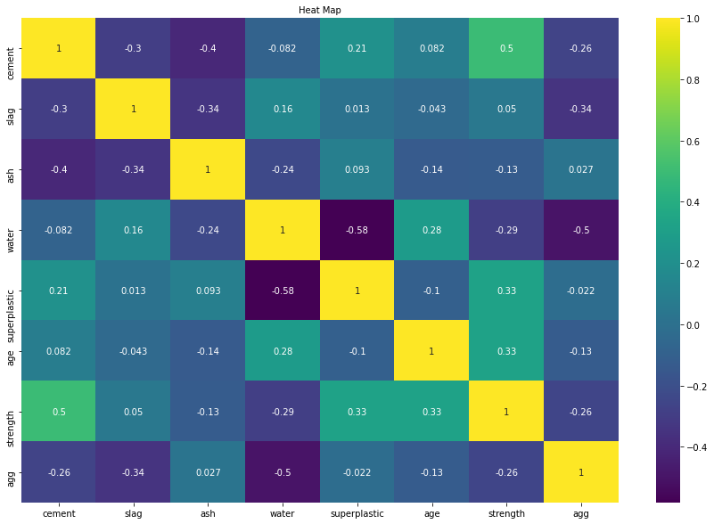

```python
#lets observe the correlaation through heat map
plt.figure(figsize = (15, 10))
plt.xticks(fontsize = 10)
plt.yticks(fontsize = 10)
plt.title('Heat Map', fontsize = 10)
sns.heatmap(corr, annot = True, cmap = 'viridis')
```

We can see the highest correlation is between strength and cement which is 0.5

##### Lets get the data model ready and do a train test split.

```python
#Defining X and y variables
X = df3_concreteZ.drop('strength', axis=1)
y = df3_concreteZ['strength']
X.head()
```

|  | cement | slag | ash | water | superplastic | age | agg |
| --- | --- | --- | --- | --- | --- | --- | --- |
| 0 | -1.339017 | 1.692620 | -0.746448 | 1.027590 | -0.565943 | -0.279733 | -0.258923 |
| 1 | -1.074790 | -1.062616 | 1.011089 | -1.090116 | 0.573179 | -0.501465 | 1.289709 |
| 2 | -0.298384 | -0.548308 | 0.294153 | 0.273274 | -0.740619 | -0.279733 | 0.707613 |
| 3 | -0.145209 | 0.102437 | -0.746448 | 2.175461 | -0.565943 | -0.279733 | -1.428057 |
| 4 | -1.209776 | 1.228546 | -0.746448 | 0.549700 | 0.151772 | -0.279733 | -0.023713 |

```python
#Split into training and test set
from sklearn.model_selection import train_test_split

X_train, X_test, y_train, y_test = train_test_split(X, y, test_size=0.30, random_state=1)
```

###### Decide on the complexity of the model, should it be a simple linear model in terms of parameters or would a quadratic or higher degree

```python
#Linear Regression
from sklearn.linear_model import LinearRegression
from sklearn.metrics import mean_squared_error, r2_score

model = LinearRegression()
model.fit(X_train, y_train)
y_predict = model.predict(X_test)

RMSE_lr = np.sqrt(mean_squared_error(y_test, y_predict))
r2_lr = r2_score(y_test, y_predict)
print(RMSE_lr)
print(r2_lr)
```

```
0.6240968977684398
0.6268686735706244
```

```python
#Polynomial linear regression of degree 2 (quadratic)
from sklearn.preprocessing import PolynomialFeatures

polynomial_features2 = PolynomialFeatures(2)

X_train_polynom = polynomial_features2.fit_transform(X_train)
X_test_polynom = polynomial_features2.fit_transform(X_test)

model = LinearRegression()
model.fit(X_train_polynom, y_train)
y_poly_predict = model.predict(X_test_polynom)

RMSE_pl2 = np.sqrt(mean_squared_error(y_test, y_poly_predict))
r2_pl2 = r2_score(y_test, y_poly_predict)
print(RMSE_pl2)
print(r2_pl2)
```

```
0.503212559513482
0.7574168627646298
```

```python
#Polynomial linear regression of degree 3 (cubic)
from sklearn.preprocessing import PolynomialFeatures

polynomial_features3 = PolynomialFeatures(3)

X_train_polynom = polynomial_features3.fit_transform(X_train)
X_test_polynom = polynomial_features3.fit_transform(X_test)

model = LinearRegression()
model.fit(X_train_polynom, y_train)
y_poly_predict = model.predict(X_test_polynom)

RMSE_pl3 = np.sqrt(mean_squared_error(y_test, y_poly_predict))
r2_pl3 = r2_score(y_test, y_poly_predict)

print(RMSE_pl3)
print(r2_pl3)
```

```
0.412709778475555
0.8368274193601339
```

##### Conclusions

1. From the above calculations of linear regression vs polynomial regression, it is quite clear that polynomial regregression able to fit the data better than the linear regression
2. RMSE has decreased and r2-score has increased as compared to the linear regression.
3. Polynomial regression of degree 3(cubic) fits better than that of degree 2 (quadratic). But if we further increase the degree the model will become overfit.

### Creating the Model and Tuning It

#### 1. Algorithms that you think will be suitable for this project (15)

###### Ridge regression

```python
#Ridge regression on linear
ridgeR = Ridge(alpha = 0.3)
ridgeR.fit(X_train, y_train)

y_ridge_predict = ridgeR.predict(X_test)

RMSE_rd = np.sqrt(mean_squared_error(y_test, y_ridge_predict))
r2_rd = r2_score(y_test, y_ridge_predict)

print(RMSE_rd)
print(r2_rd)
```

```
0.6242016633565536
0.6267433898075478
```

```python
#Ridge regression on polynomial model
ridgeRP = Ridge(alpha = 0.3)
ridgeRP.fit(X_train_polynom, y_train)

y_ridgeP_predict = ridgeRP.predict(X_test_polynom)

RMSE_rdp = np.sqrt(mean_squared_error(y_test, y_ridgeP_predict))
r2_rdp = r2_score(y_test, y_ridgeP_predict)

print(RMSE_rdp)
print(r2_rdp)
```

```
0.4049579495547439
0.8428995163653651
```

###### Lasso Regression

```python
#Lasso Regression on linear
lassoR = Lasso(alpha = 0.02)
lassoR.fit(X_train, y_train)

y_lasso_predict = lassoR.predict(X_test)

RMSE_ls = np.sqrt(mean_squared_error(y_test, y_lasso_predict))
r2_ls = r2_score(y_test, y_lasso_predict)

print(RMSE_ls)
print(r2_ls)
```

```
0.6390658056251898
0.6087549776255954
```

```python
#Lasso regression on Polynomial model
lassoRP = Lasso(alpha = 0.02)
lassoRP.fit(X_train_polynom, y_train)

y_lassoP_predict = lassoRP.predict(X_test_polynom)

RMSE_lsp = np.sqrt(mean_squared_error(y_test, y_lassoP_predict))
r2_lsp = r2_score(y_test, y_lassoP_predict)

print(RMSE_lsp)
print(r2_lsp)
```

```
0.4850285116785771
0.7746320253505145
```

###### Bagging Regression

```python
#Bagging regression on linear model
baggingR = BaggingRegressor()
baggingR.fit(X_train, y_train)

y_bagging_predict = baggingR.predict(X_test)

RMSE_bg = np.sqrt(mean_squared_error(y_test, y_bagging_predict))
r2_bg = r2_score(y_test, y_bagging_predict)

print(RMSE_bg)
print(r2_bg)
```

```
0.3387829391047657
0.8900486092104533
```

```python
#Bagging regression on polynomial model
baggingRP = BaggingRegressor()
baggingRP.fit(X_train_polynom, y_train)

y_baggingP_predict = baggingRP.predict(X_test_polynom)

RMSE_bgp = np.sqrt(mean_squared_error(y_test, y_baggingP_predict))
r2_bgp= r2_score(y_test, y_baggingP_predict)

print(RMSE_bgp)
print(r2_bgp)
```

```
0.3854774324257746
0.8576506201296946
```

###### Gradient Boosting regression

```python
#Gradient Boosting regression on linear model
gradientboostingR = GradientBoostingRegressor()
gradientboostingR.fit(X_train, y_train)

y_gradientboosting_predict = gradientboostingR.predict(X_test)

RMSE_gb = np.sqrt(mean_squared_error(y_test, y_gradientboosting_predict))
r2_gb = r2_score(y_test, y_gradientboosting_predict)

print(RMSE_gb)
print(r2_gb)
```

```
0.34936579460635403
0.88307202491992
```

```python
#Gradient Boosting regression on polynomial model
gradientboostingRP = GradientBoostingRegressor()
gradientboostingRP.fit(X_train_polynom, y_train)

y_gradientboostingP_predict = gradientboostingRP.predict(X_test_polynom)

RMSE_gbp = np.sqrt(mean_squared_error(y_test, y_gradientboostingP_predict))
r2_gbp = r2_score(y_test, y_gradientboostingP_predict)

print(RMSE_gbp)
print(r2_gbp)
```

```
0.3472092134371397
0.8845111262073762
```

###### XGBoosting regression

```python
#XGBoost regression on linear model
xgb_l = XGBRegressor(max_depth=5, learning_rate=0.2, n_estimators=100, objective='reg:squarederror', booster='gbtree')
xgb_l.fit(X_train, y_train)

y_xgb_predict = xgb_l.predict(X_test)

RMSE_xgbl = np.sqrt(mean_squared_error(y_test, y_xgb_predict))
r2_xgbl = r2_score(y_test, y_xgb_predict)

print(RMSE_xgbl)
print(r2_xgbl)
```

```
0.3127516864858877
0.9062962471310144
```

```python
#XGBoost regression on polynomial model
xgb_p = XGBRegressor(max_depth=5, learning_rate=0.2, n_estimators=100, objective='reg:squarederror', booster='gbtree')
xgb_p.fit(X_train_polynom, y_train)

y_xgbP_predict = xgb_p.predict(X_test_polynom)

RMSE_xgbp = np.sqrt(mean_squared_error(y_test, y_xgbP_predict))
r2_xgbp = r2_score(y_test, y_xgbP_predict)

print(RMSE_xgbp)
print(r2_xgbp)
```

```
0.3277950153112598
0.8970651693075501
```

###### RandomForest Regression

```python
#RandomForest regression on linear model
randomforestR = RandomForestRegressor()
randomforestR.fit(X_train, y_train)

y_randomforest_predict = randomforestR.predict(X_test)

RMSE_rf = np.sqrt(mean_squared_error(y_test, y_randomforest_predict))
r2_rf = r2_score(y_test, y_randomforest_predict)

print(RMSE_rf)
print(r2_rf)
```

```
0.31178753155223005
0.9068730988716264
```

```python
#RandomForest regression on polynomial model
randomforestRP = RandomForestRegressor()
randomforestRP.fit(X_train_polynom, y_train)

y_randomforestP_predict = randomforestRP.predict(X_test_polynom)

RMSE_rfp = np.sqrt(mean_squared_error(y_test, y_randomforestP_predict))
r2_rfp = r2_score(y_test, y_randomforestP_predict)

print(RMSE_rfp)
print(r2_rfp)
```

```
0.356860099479115
0.8780017365774896
```

```python
#Let's summarize all the models with their best r2 score
modellists = []

modellists.append(['Linear Regression',RMSE_lr , r2_lr ])
modellists.append(['Polynomial Regression', RMSE_pl3, r2_pl3])
modellists.append(['Ridge Regression polynomial', RMSE_rdp, r2_rdp])
modellists.append(['Lasso Regression Polynomial', RMSE_lsp, r2_lsp])
modellists.append(['Bagging Regression Linear', RMSE_bg, r2_bg])
modellists.append(['Gradient Boosting Regression Polynomial', RMSE_gbp, r2_gbp])
modellists.append(['XGBoosting Regression linear', RMSE_xgbl, r2_xgbl])
modellists.append(['Random Forest Regression Linear', RMSE_rf, r2_rf])

model_df1 = pd.DataFrame(modellists, columns = ['Model', 'RMSE', 'R2 Score of Validation Data'])
model_df1
```

|  | Model | RMSE | R2 Score of Validation Data |
| --- | --- | --- | --- |
| 0 | Linear Regression | 0.624097 | 0.626869 |
| 1 | Polynomial Regression | 0.412710 | 0.836827 |
| 2 | Ridge Regression polynomial | 0.404958 | 0.842900 |
| 3 | Lasso Regression Polynomial | 0.485029 | 0.774632 |
| 4 | Bagging Regression Linear | 0.338783 | 0.890049 |
| 5 | Gradient Boosting Regression Polynomial | 0.347209 | 0.884511 |
| 6 | XGBoosting Regression linear | 0.312752 | 0.906296 |
| 7 | Random Forest Regression Linear | 0.311788 | 0.906873 |

Conclusion

1. The above table shows the diffrent regression models (either in linear or polynomial model) which shows highest r2 score(accuracy) and comparatively lower RMSE value.
2. We can see Random forest regession for linear model has the hihjest accuracy(90.68) tha the rest of the models

#### 2. Techniques employed to squeeze that extra performance out of the model without making it overfit (15)

Let's further tune the model using Grid searach and the calculating cross validation score to finalize the best fit model to predict the concrete strength.

###### Parameter Tuning Using GridDSearch and cross validation score

```python
#Random forest
parameters = {'bootstrap': [True],
 'max_depth': [10, 20, 30, 40, 50],
 'max_features': ['auto', 'sqrt'],
 'min_samples_leaf': [1, 2, 4, 8],
 'n_estimators': [100]}


clf = GridSearchCV(RandomForestRegressor(), parameters, cv = 5, verbose = 2, n_jobs= 4)
clf.fit(X, y)

clf.best_params_
```

```
Fitting 5 folds for each of 40 candidates, totalling 200 fits
```

```
[Parallel(n_jobs=4)]: Using backend LokyBackend with 4 concurrent workers.
[Parallel(n_jobs=4)]: Done  33 tasks      | elapsed:    3.6s
[Parallel(n_jobs=4)]: Done 154 tasks      | elapsed:    9.0s
[Parallel(n_jobs=4)]: Done 200 out of 200 | elapsed:   11.2s finished
```

```
{'bootstrap': True,
 'max_depth': 40,
 'max_features': 'auto',
 'min_samples_leaf': 1,
 'n_estimators': 100}
```

```python
randomforestR = RandomForestRegressor(bootstrap= True,
 max_depth= 40,
 max_features= 'auto',
 min_samples_leaf= 1,
 n_estimators= 100)


r2_rfcv = cross_val_score(randomforestR, X, y, cv = 5).mean()


r2_rfcv
```

```
0.9049962125577125
```

```python
#XGBoosting
params = {'min_child_weight':[4,5], 'gamma':[i/10.0 for i in range(3,6)],  'subsample':[i/10.0 for i in range(6,11)],
'colsample_bytree':[i/10.0 for i in range(6,11)], 'max_depth': [2,3,4], 'objective': ['reg:squarederror']}
xgb = XGBRegressor(nthread=-1)

grid_xgb = GridSearchCV(xgb, params, cv = 5)
grid_xgb.fit(X, y)

grid_xgb.best_params_
```

```
{'colsample_bytree': 0.8,
 'gamma': 0.3,
 'max_depth': 4,
 'min_child_weight': 5,
 'objective': 'reg:squarederror',
 'subsample': 0.9}
```

```python
xgb_l = XGBRegressor(colsample_bytree = 0.8,
        gamma = 0.3,
        max_depth = 4,
        min_child_weight = 5,
        subsample = 0.9)

r2_xgb = cross_val_score(xgb_l, X, y, cv = 5).mean()
r2_xgb
```

```
0.916538890935735
```

```python
#Let's summarize both models and chek the best fit model
model_lists = []

model_lists.append(['Random Forest Regression', r2_rfcv ])
model_lists.append(['XGBoosting Regression', r2_xgb])

model_df2 = pd.DataFrame(model_lists, columns = ['Model', 'cross validation accuracy score'])
model_df2
```

|  | Model | cross validation accuracy score |
| --- | --- | --- |
| 0 | Random Forest Regression | 0.904996 |
| 1 | XGBoosting Regression | 0.916539 |

###### From the above observation we can see that XGBoosting Regression has the highest cross validation accuracy score(91.65) and hence conclude the best fit model to predict the strength of concrete.